# Modeling Relational Event Dynamics with statnet

Carter T. Butts

*Last updated 2022-06-24*

*This tutorial is a joint product of the Statnet Development Team:*

Pavel N. Krivitsky (University of New South Wales)  
Martina Morris (University of Washington)  
Mark S. Handcock (University of California, Los Angeles)  
Carter T. Butts (University of California, Irvine)  
David R. Hunter (Penn State University)  
Steven M. Goodreau (University of Washington)  
Chad Klumb (University of Washington)  
Skye Bender de-Moll (Oakland, CA)

The network modeling software demonstrated in this tutorial is authored by Carter Butts (`relevent`, `sna`).

## The `statnet` Project

All `statnet` packages are open-source, written for the **R** computing environment, and published on CRAN. The source repositories are hosted on [GitHub](https://github.com/statnet). Our website is [statnet.org](http://statnet.org/)

- Need help? For general questions and comments, please email the statnet users group at statnet_help@uw.edu. You’ll need to join the listserv if you’re not already a member. You can do that here: [statnet_help listserve](https://mailman13.u.washington.edu/mailman/listinfo/statnet_help).
- Found a bug in our software? Please let us know by filing an issue in the appropriate package [GitHub repository](https://github.com/statnet), with a reproducible example.
- Want to request new functionality? We welcome suggestions – you can make a request by filing an issue on the appropriate package [GitHub repository](https://github.com/statnet). The chances that this functionality will be developed are substantially improved if the requests are accompanied by some proposed code (we are happy to review pull requests).
- For all other issues, please email us at contact@statnet.org.

## Section 0. Introduction to the Tutorial

This workshop and tutorial provide an introduction to statistical modeling of relational event data using `statnet` software. This online tutorial is also designed for self-study, with example code and self-contained data. The `statnet` package we will be demonstrating is:

- `relevent` – modeling and simulation for relational event models

Additional background on the tools, modeling framework, and data used in this tutorial may be found in the references at the bottom of this document.

### 0.0 Prerequisites

This workshop assumes basic familiarity with **R**, experience with network concepts, terminology and data, and familiarity with the general framework for statistical modeling and inference. While previous experience with relational event models (REMs) is not required, some of the topics covered here may be difficult to understand without a strong background in linear and generalized linear models in statistics.

### 0.1 Software installation

Minimally, you will need to install the latest version of **R** [(available here)](https://cran.r-project.org) and the `statnet` packages `relevent`, `sna` and `network` to run the code presented here (`sna` will automatically install `network` when it is installed).

The full set of installation instructions with details can be found on the [`statnet` workshop wiki](https://github.com/statnet/Workshops/wiki/Software-Installation-Instructions).

If you have not already downloaded the `statnet` packages for this workshop, the quickest way to install these (and the other most commonly used packages from the `statnet` suite), is to open an R session and type:

```r
install.packages(c("relevent","sna"))
```

```r
library(relevent)
library(sna)
```

You can check the version number with:

```r
packageVersion("relevent")
```

```
[1] '1.1'
```

Throughout, we will set a random seed via `set.seed()` for commands in tutorial that require simulating random values—this is not necessary, but it ensures that you will get the same results as the online tutorial.

## Section 1. Dyadic Relational Event Models with `rem.dyad`: Ordinal Timing

Dyadic relational event models are intended to capture the behavior of systems in which individual social units (persons, organizations, animals, etc.) direct discrete actions towards other individuals in their environment. Within the `relevent` package, the `rem.dyad` function is the primary workhorse for modeling dyadic data. Although less flexible than `rem` (another `relevent` tool, not covered in this tutorial), `rem.dyad` contains many features that make it easier to work with in the dyadic case.

Data for use with `rem.dyad` consists of dynamic edge lists, each edge being characterized by a sender, a recipient, and an event time. (Currently, self-edges and undirected edges are not supported – this will change in future versions!) Ideally, event times are known exactly; however, under the piecewise constant hazard assumption (per Butts, 2008) the relational event family can still be identified up to a pacing constant so long as the order of events is known. Since the case of ordinal timing is somewhat simpler than that of exact timing, we consider it first.

### 1.0 Loading the `relevent` package, and the workshop data

```r
library(relevent)  #Load the relevent library
load("relevent_workshop.Rdata")  #Load the workshop data - may need to change directory!
```

### 1.1 Getting a look at the WTC Police radio data

The data we will use here comes from the World Trade Center radio communication data set coded by Butts et al. (2007). It consists of radio calls among 37 named communicants belonging to a police unit at the World Trade Center complex on the morning of 9/11/2001. The edgelist is contained in an object called `WTCPoliceCalls`; printing it should yield output like the following:

```r
WTCPoliceCalls
```

```
    number source recipient
1        1     16        32
2        2     32        16
3        3     16        32
4        4     16        32
5        5     11        32
6        6     11        32
7        7     11        32
8        8     36        32
9        9      8        32
10      10      8        32
11      11     32         8
12      12     16        32
13      13      8        32
14      14     26        32
```

[output cut: 467 more lines]

Note the form of the data: a matrix with the timing information, source (numbered from 1 to 37), and recipient (again numbered from 1 to 37) for each event (i.e., radio call). It is important to note that the WTC radio data was coded from transcripts that lacked detailed timing information; we do not therefore know precisely when these calls were made. We do, however, know the order in which calls were made, and can use this to fit relational event models with `rem.dyad`.

Before analyzing the data, it is helpful to consider what it looks like in time aggregated form. The workshop-supplied helper function `as.sociomatrix.eventlist` is useful for this purpose: it converts an event list into a valued sociomatrix, of the form used by other `statnet` routines. Let’s convert the data to sociomatrix form, and visualize it using the `gplot` function of the `sna` package:

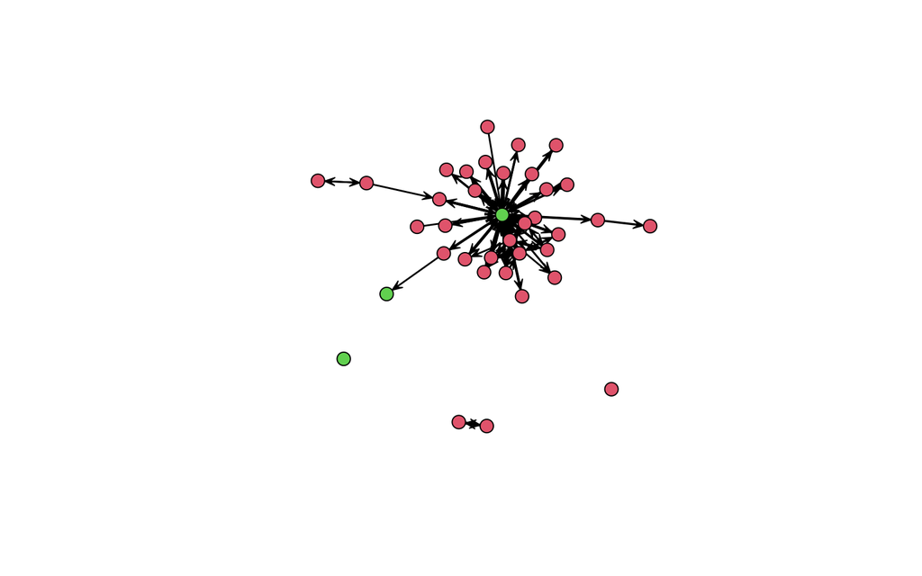

```r
WTCPoliceNet <- as.sociomatrix.eventlist(WTCPoliceCalls, 37)
gplot(WTCPoliceNet, edge.lwd = WTCPoliceNet^0.75, vertex.col = 2 +
   WTCPoliceIsICR, vertex.cex = 1.25)
```

In this visualization, we have scaled edge widths by communication volume – clearly, some pairs interact much more than others. Note also that we have colored vertices based on whether or not they occupy an institutionalized coordinative role (ICR), as indicated by the vector `WTCPoliceIsICR`. Those for whom this vector is TRUE (green) occupy roles within the police organization that would be expected to participate in coordinative activities; other actors were not identified as occupying such roles, based on the transcript data. In the analyses below, we will employ this covariate (as well as various endogenous mechanisms) to model the dynamics of radio communication within the WTC police network.

### 1.2 A first model: exploring ICR effects

Let’s begin by fitting a very simple covariate model, in which the propensity of individuals to send and receive calls depends on whether they occupy institutionalized coordinative roles:

```r
# First ICR effect - total interaction
wtcfit1 <- rem.dyad(WTCPoliceCalls, n = 37, effects = c("CovInt"),
   covar = list(CovInt = WTCPoliceIsICR), hessian = TRUE)
```

```
Prepping edgelist.
Checking/prepping covariates.
Computing preliminary statistics
Fitting model
Obtaining goodness-of-fit statistics
```

```r
summary(wtcfit1)
```

```
Relational Event Model (Ordinal Likelihood)

         Estimate  Std.Err Z value  Pr(>|z|)
CovInt.1 2.104464 0.069817  30.142 < 2.2e-16 ***
---
Signif. codes:  0 '***' 0.001 '**' 0.01 '*' 0.05 '.' 0.1 ' ' 1
Null deviance: 6921.048 on 481 degrees of freedom
Residual deviance: 6193.998 on 480 degrees of freedom
    Chi-square: 727.0499 on 1 degrees of freedom, asymptotic p-value 0
AIC: 6195.998 AICC: 6196.007 BIC: 6200.174
```

The output gives us the covariate effect, as well as some uncertainty and goodness-of-fit information. The format is much like the output for a regression model, but coefficients should be interpreted per the relational event framework. In particular, the ICR role coefficient is the logged multiplier for the hazard of an event involving an ICR, versus a non-ICR event. (The effect is cumulative: an event in which one actor in an ICR calls another actor in an ICR gets twice the log increment.) We can see this impact in real terms as follows:

```r
exp(wtcfit1$coef)  #Relative hazard for a non-ICR/ICR vs. a non-ICR/non-ICR event
```

```
CovInt.1
8.202708
```

```r
exp(2 * wtcfit1$coef)  #Relative hazard for an ICR/ICR vs. a non-ICR/non-ICR event
```

```
CovInt.1
67.28442
```

We have here considered a homogeneous effect of ICR status on sending and receiving; is it worth treating these effects separately? To do so, we enter the ICR covariate as a sender and receiver covariate (respectively):

```r
wtcfit2 <- rem.dyad(WTCPoliceCalls, n = 37, effects = c("CovSnd",
   "CovRec"), covar = list(CovSnd = WTCPoliceIsICR, CovRec = WTCPoliceIsICR),
   hessian = TRUE)
```

```
Prepping edgelist.
Checking/prepping covariates.
Computing preliminary statistics
Fitting model
Obtaining goodness-of-fit statistics
```

```r
summary(wtcfit2)
```

```
Relational Event Model (Ordinal Likelihood)

         Estimate  Std.Err Z value  Pr(>|z|)
CovSnd.1 1.979175 0.095745  20.671 < 2.2e-16 ***
CovRec.1 2.225720 0.092862  23.968 < 2.2e-16 ***
---
Signif. codes:  0 '***' 0.001 '**' 0.01 '*' 0.05 '.' 0.1 ' ' 1
Null deviance: 6921.048 on 481 degrees of freedom
Residual deviance: 6190.175 on 479 degrees of freedom
    Chi-square: 730.8731 on 2 degrees of freedom, asymptotic p-value 0
AIC: 6194.175 AICC: 6194.2 BIC: 6202.527
```

Does the effect seem to differ? Let’s see if fit improves (using the BIC):

```r
wtcfit1$BIC - wtcfit2$BIC  #Model 1 a bit lower - we prefer it
```

```
[1] -2.352663
```

Model selection criteria are the preferred way to compare models, but one can also use a test of equality on the coefficients:

```r
wtcfit2$coef  #Extract the coefficients
```

```
CovSnd.1 CovRec.1
1.979175 2.225720
```

```r
wtcfit2$cov  #Likewise, the posterior covariance matrix
```

```
             [,1]         [,2]
[1,] 0.0091670943 0.0009005436
[2,] 0.0009005436 0.0086233446
```

```r
# Heuristic Wald test of equality (not Bayesian, but
# whatever)
z <- diff(wtcfit2$coef)/sqrt(sum(diag(wtcfit2$cov)) - 2 * wtcfit2$cov[1,
   2])
z
```

```
CovRec.1
1.949757
```

```r
2 * (1 - pnorm(abs(z)))  #Not conventionally significant - not strongly detectable
```

```
 CovRec.1
0.0512051
```

There might be some difference between the ICR sender and receiver effects, but it doesn’t seem large enough to worry about. For now, we’ll just stick with the simpler model (with a uniform effect on total interaction).

### 1.3 Bringing in endogenous social dynamics

One of the attractions of the relational event framework is its ability to capture endogenous social dynamics. In the following examples, we will examine several kinds of mechanisms that could conceivably impact communication among participants in the WTC police network. In each case, we first fit a candidate model, then compare that model to our best fitting model thus far identified. Where effects result in an improvement (as judged by the BIC), we include them in subsequent models.

To begin, we note that this is radio communication data. Radio communication is governed by strong conversational norms (in particular, radio SOP), which among other things mandate systematic turn-taking reciprocity. We can test for this via the use of participation shifts, particularly the AB-BA shift (a tendency for B to call A, given that A has just called B).

```r
wtcfit3 <- rem.dyad(WTCPoliceCalls, n = 37, effects = c("CovInt",
   "PSAB-BA"), covar = list(CovInt = WTCPoliceIsICR), hessian = TRUE)
```

```
Prepping edgelist.
Checking/prepping covariates.
Computing preliminary statistics
Fitting model
Obtaining goodness-of-fit statistics
```

```r
summary(wtcfit3)  #Looks like a strong effect...
```

```
Relational Event Model (Ordinal Likelihood)

         Estimate Std.Err Z value  Pr(>|z|)
CovInt.1  1.60405 0.11500  13.949 < 2.2e-16 ***
PSAB-BA   7.32695 0.10552  69.436 < 2.2e-16 ***
---
Signif. codes:  0 '***' 0.001 '**' 0.01 '*' 0.05 '.' 0.1 ' ' 1
Null deviance: 6921.048 on 481 degrees of freedom
Residual deviance: 2619.115 on 479 degrees of freedom
    Chi-square: 4301.933 on 2 degrees of freedom, asymptotic p-value 0
AIC: 2623.115 AICC: 2623.14 BIC: 2631.467
```

```r
wtcfit1$BIC - wtcfit3$BIC  #We prefer model 3 to model 1 - reciprocity is in!
```

```
[1] 3568.707
```

```r
exp(wtcfit3$coef["PSAB-BA"])  #Reciprocating events are >1500 times as likely
```

```
PSAB-BA
1520.73
```

What about other conversational norms? In general, we may expect that the current participants in an interaction may be likely to initiate the next call, a tendency that can also be captured with P-shift effects.

```r
wtcfit4 <- rem.dyad(WTCPoliceCalls, n = 37, effects = c("CovInt",
   "PSAB-BA", "PSAB-BY", "PSAB-AY"), covar = list(CovInt = WTCPoliceIsICR),
   hessian = TRUE)
```

```
Prepping edgelist.
Checking/prepping covariates.
Computing preliminary statistics
Fitting model
Obtaining goodness-of-fit statistics
```

```r
summary(wtcfit4)  #Seems like the effects are present, but let's test GOF...
```

```
Relational Event Model (Ordinal Likelihood)

         Estimate Std.Err Z value  Pr(>|z|)
CovInt.1  1.54283 0.11818 13.0549 < 2.2e-16 ***
PSAB-BA   7.49955 0.11418 65.6831 < 2.2e-16 ***
PSAB-BY   1.25942 0.25131  5.0115 5.401e-07 ***
PSAB-AY   0.87217 0.30611  2.8492  0.004384 **
---
Signif. codes:  0 '***' 0.001 '**' 0.01 '*' 0.05 '.' 0.1 ' ' 1
Null deviance: 6921.048 on 481 degrees of freedom
Residual deviance: 2595.135 on 477 degrees of freedom
    Chi-square: 4325.913 on 4 degrees of freedom, asymptotic p-value 0
AIC: 2603.135 AICC: 2603.219 BIC: 2619.839
```

```r
wtcfit3$BIC - wtcfit4$BIC  #Yes, definite improvement
```

```
[1] 11.62806
```

P-shift effects are “local,” in that they depend only on the prior event. What about effects of recency (from the point of view of ego) on the tendency to send calls to others?

```r
wtcfit5 <- rem.dyad(WTCPoliceCalls, n = 37, effects = c("CovInt",
   "PSAB-BA", "PSAB-BY", "PSAB-AY", "RRecSnd", "RSndSnd"), covar = list(CovInt = WTCPoliceIsICR),
   hessian = TRUE)
```

```
Prepping edgelist.
Checking/prepping covariates.
Computing preliminary statistics
Fitting model
Obtaining goodness-of-fit statistics
```

```r
summary(wtcfit5)  #Looks good; note that AB-BA is much smaller than before
```

```
Relational Event Model (Ordinal Likelihood)

         Estimate Std.Err Z value  Pr(>|z|)
RRecSnd   2.38495 0.27447  8.6891 < 2.2e-16 ***
RSndSnd   1.34624 0.22307  6.0350 1.590e-09 ***
CovInt.1  1.07058 0.14244  7.5160 5.640e-14 ***
PSAB-BA   4.88714 0.15293 31.9569 < 2.2e-16 ***
PSAB-BY   1.67939 0.26116  6.4304 1.273e-10 ***
PSAB-AY   1.39018 0.31057  4.4763 7.596e-06 ***
---
Signif. codes:  0 '***' 0.001 '**' 0.01 '*' 0.05 '.' 0.1 ' ' 1
Null deviance: 6921.048 on 481 degrees of freedom
Residual deviance: 2307.413 on 475 degrees of freedom
    Chi-square: 4613.635 on 6 degrees of freedom, asymptotic p-value 0
AIC: 2319.413 AICC: 2319.591 BIC: 2344.469
```

```r
wtcfit4$BIC - wtcfit5$BIC  #Substantial improvement
```

```
[1] 275.3701
```

Finally, recall what our relational event data looked like when viewed in time-aggregated form. We observed a strongly hub-dominated network, with a few actors doing most of the communication. Could this be explained in part via a preferential attachment mechanism (per de Sola Price and others), in which those having the most air time become the most attractive targets for others to call? We can investigate this by including normalized total degree as a predictor of tendency to receive calls:

```r
wtcfit6 <- rem.dyad(WTCPoliceCalls, n = 37, effects = c("CovInt",
   "PSAB-BA", "PSAB-BY", "PSAB-AY", "RRecSnd", "RSndSnd", "NTDegRec"),
   covar = list(CovInt = WTCPoliceIsICR), hessian = TRUE)
```

```
Prepping edgelist.
Checking/prepping covariates.
Computing preliminary statistics
Fitting model
Obtaining goodness-of-fit statistics
```

```r
summary(wtcfit6)  #PA is drawing from recency, ICR effect, but not P-shifts
```

```
Relational Event Model (Ordinal Likelihood)

         Estimate Std.Err Z value  Pr(>|z|)
NTDegRec  3.13454 0.56678  5.5305 3.194e-08 ***
RRecSnd   2.02903 0.28500  7.1194 1.084e-12 ***
RSndSnd   0.87116 0.23846  3.6533 0.0002589 ***
CovInt.1  0.70734 0.16400  4.3130 1.611e-05 ***
PSAB-BA   5.32576 0.18236 29.2042 < 2.2e-16 ***
PSAB-BY   1.86023 0.26322  7.0673 1.579e-12 ***
PSAB-AY   1.64806 0.31092  5.3005 1.155e-07 ***
---
Signif. codes:  0 '***' 0.001 '**' 0.01 '*' 0.05 '.' 0.1 ' ' 1
Null deviance: 6921.048 on 481 degrees of freedom
Residual deviance: 2276.263 on 474 degrees of freedom
    Chi-square: 4644.785 on 7 degrees of freedom, asymptotic p-value 0
AIC: 2290.263 AICC: 2290.5 BIC: 2319.494
```

```r
wtcfit5$BIC - wtcfit6$BIC  #Model is preferred
```

```
[1] 24.97434
```

At this point, we’ve got a decent quorum of effects, and the deviance reduction is substantial. Of course, we could continue to investigate other mechanisms; see `?rem.dyad` for the full range of options.

### 1.4 Assessing model adequacy

Model adequacy is an important consideration: even given that our model is the best of those we’ve seen, is it good enough for our purposes? There are many ways to assess model adequacy; here, we focus on the ability of the relational event model to predict the next event in the sequence, given those that have come before. A natural question to ask when assessing the model is to ask when it is “surprised:” when does it encounter observations that are relatively poorly predicted? To investigate this, we can examine the deviance residuals:

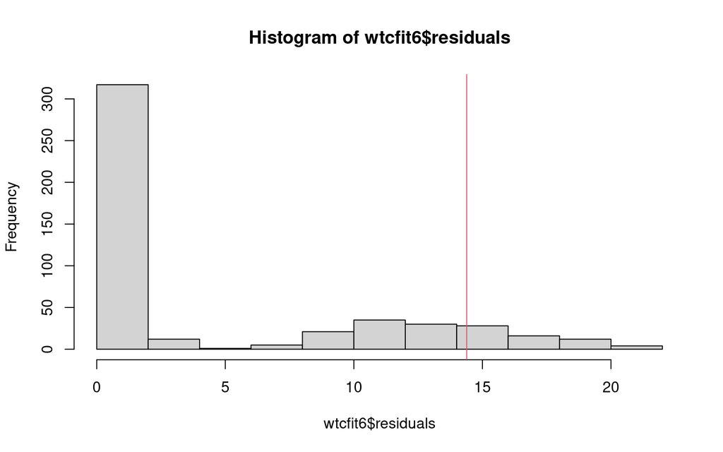

```r
nullresid <- 2 * log(37 * 36)  #What would be the deviance residual for the null?
hist(wtcfit6$residuals)  #Deviance residuals - most well-predicted, some around chance levels
abline(v = nullresid, col = 2)
```

```r
mean(wtcfit6$residuals < nullresid)  #Beating chance on almost all...
```

```
[1] 0.8898129
```

```r
mean(wtcfit6$residuals < 3)  #Upper limit of lower cluster is about 3
```

```
[1] 0.6839917
```

We seem to be doing pretty well here. As another way of evaluating the deviance residuals for the ordinal model, it is useful to note that the quantity $\exp(DR/2)$ (where $DR$ is the deviance residual) is a “random guessing equivalent,” or an effective number of events such that a random guess among such events as to which is coming next would be right as often as the model expects to be. We can easily compute this as follows:

```r
quantile(exp(wtcfit6$residuals/2))  #'Random guessing equivalent' (ref is 1332)
```

```
          0%          25%          50%          75%         100%
    1.073634     1.268661     1.739723   204.539108 31633.027550
```

Note that there are 1332 possible events, so we are doing much, much better than an uninformative baseline. Likewise, we’ve come a long way from our initial model:

```r
quantile(exp(wtcfit1$residuals/2))  #By comparison, first model much worse!
```

```
       0%       25%       50%       75%      100%
 390.0003  390.0003  390.0003  390.0003 3199.0589
```

In addition to overall examination of residuals, it can be useful to ask which particular events seem to be sources of surprise:

```r
cbind(WTCPoliceCalls, wtcfit6$residuals > nullresid)  #Which are the more surprising cases?
```

```
    number source recipient wtcfit6$residuals > nullresid
1        1     16        32                         FALSE
2        2     32        16                         FALSE
3        3     16        32                         FALSE
4        4     16        32                         FALSE
5        5     11        32                          TRUE
6        6     11        32                         FALSE
7        7     11        32                         FALSE
8        8     36        32                         FALSE
9        9      8        32                         FALSE
10      10      8        32                         FALSE
11      11     32         8                         FALSE
12      12     16        32                         FALSE
13      13      8        32                         FALSE
14      14     26        32                          TRUE
```

[output cut: 467 more lines]

Using `as.sociomatrix.eventlist`, we can even pull out these events and view them in time-aggregated form. This can give us a better sense of the structural context in which they occur:

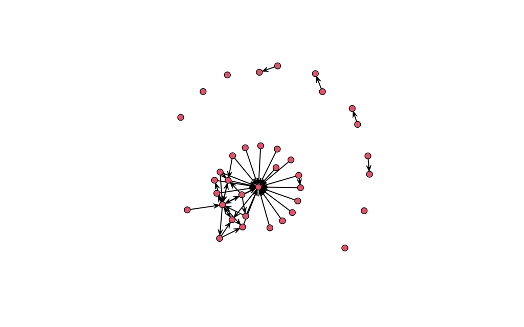

```r
surprising <- as.sociomatrix.eventlist(WTCPoliceCalls[wtcfit6$residuals >
   nullresid, ], 37)
gplot(surprising)  #Plot in network form
```

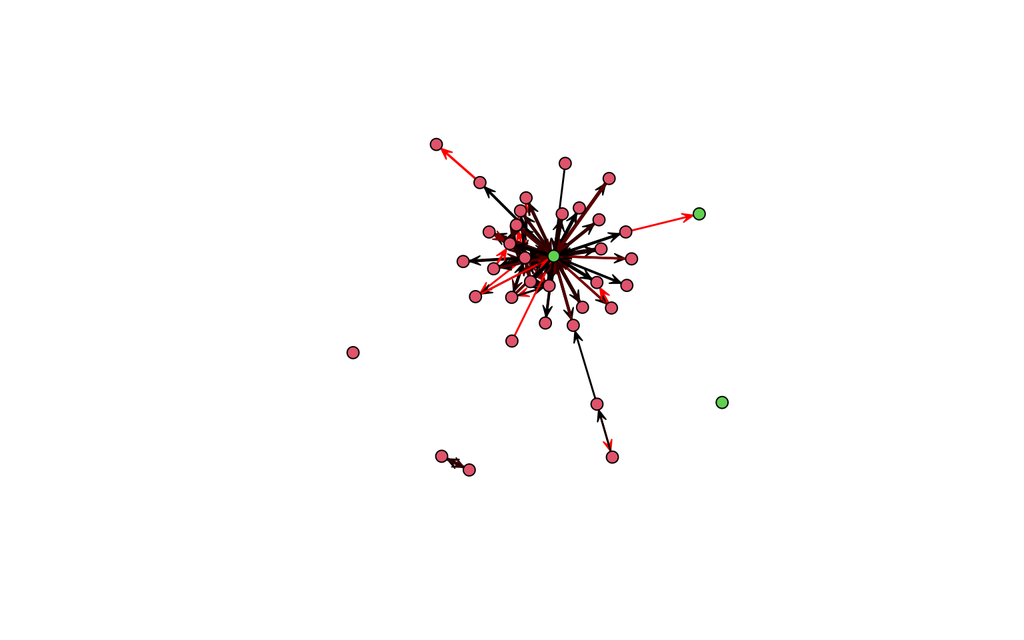

```r
# Can also superimpose on the original network (coloring
# edges by fraction surprising)
edgecol <- matrix(rgb(surprising/(WTCPoliceNet + 0.01), 0, 0),
   37, 37)  #Color me surprised
gplot(WTCPoliceNet, edge.col = edgecol, edge.lwd = WTCPoliceNet^0.75,
   vertex.col = 2 + WTCPoliceIsICR)
```

Yet another approach to adequacy assessment is to consider the rank of the observed events in the predicted rate structure: that is, we ask to what extent the events viewed most likely to occur are in fact those that are observed.

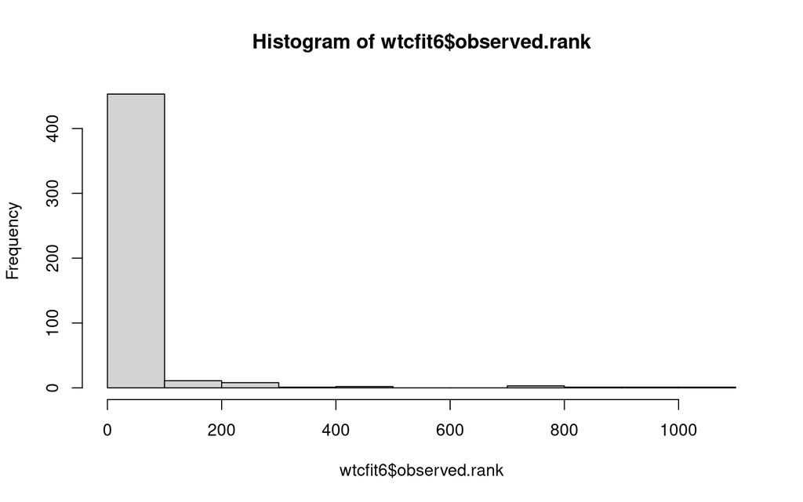

```r
hist(wtcfit6$observed.rank)
```

```r
cbind(WTCPoliceCalls, wtcfit6$observed.rank)  #Histogram of ranks
```

```
    number source recipient wtcfit6$observed.rank
1        1     16        32                     7
2        2     32        16                     1
3        3     16        32                     1
4        4     16        32                     2
5        5     11        32                    42
6        6     11        32                     6
7        7     11        32                     6
8        8     36        32                    44
9        9      8        32                    45
10      10      8        32                     8
11      11     32         8                     1
12      12     16        32                     2
13      13      8        32                     2
14      14     26        32                    45
```

[output cut: 467 more lines]

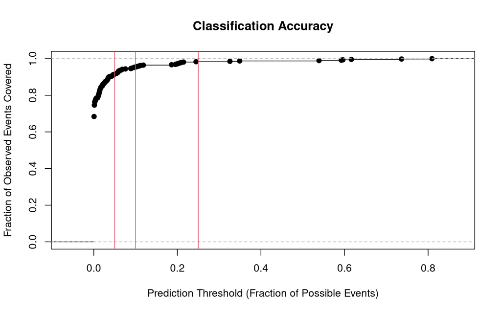

```r
# Rank on a per-event basis (low is good) Sometimes useful
# to plot the ECDF of the observed ranks....
plot(ecdf(wtcfit6$observed.rank/(37 * 36)), xlab = "Prediction Threshold (Fraction of Possible Events)",
   ylab = "Fraction of Observed Events Covered", main = "Classification Accuracy")
abline(v = c(0.05, 0.1, 0.25), col = 2)
```

As the above indicates, we sometimes (in fact often) manage to get things exactly right: that is, the event predicted most likely to be the next in the sequence is in fact the one that is observed. Examining the match rate is a very strict notion of adequacy, but can be useful for assessing models that are strongly predictive.

```r
wtcfit6$predicted.match  #Exactly correct src/target
```

```
       source recipient
  [1,]  FALSE     FALSE
  [2,]   TRUE      TRUE
  [3,]   TRUE      TRUE
  [4,]  FALSE     FALSE
  [5,]  FALSE     FALSE
  [6,]  FALSE     FALSE
  [7,]  FALSE     FALSE
  [8,]  FALSE     FALSE
  [9,]  FALSE     FALSE
 [10,]  FALSE     FALSE
 [11,]   TRUE      TRUE
 [12,]  FALSE      TRUE
 [13,]  FALSE     FALSE
 [14,]  FALSE     FALSE
```

[output cut: 467 more lines]

```r
mean(apply(wtcfit6$predicted.match, 1, any))  #Fraction for which something is right
```

```
[1] 0.7941788
```

```r
mean(apply(wtcfit6$predicted.match, 1, all))  #Fraction entirely right
```

```
[1] 0.6839917
```

```r
colMeans(wtcfit6$predicted.match)  #Fraction src/target, respectively
```

```
   source recipient
0.7234927 0.7546778
```

Despite its simplicity, this model seems to fit extremely well. Further improvement is possible, but for many purposes we might view it as an adequate representation of the event dynamics in this WTC police network.

### 1.5 Simulating from the fitted model

In addition to fitting REMs, `relevent` has tools for simulating from them. These work a bit like the `simulate` commands in the `ergm` library, in that they can be used in two modes: we can simulate draws from a fitted `rem.dyad` model; or we can simulate draws from an *a priori* specified model. For now, let’s consider this first case.

The syntax for the `rem.dyad` `simulate` method is as follows:

```r
simulate(object, nsim = object$m, seed = NULL, coef = NULL, covar = NULL,
   verbose = FALSE, ...)
```

`object` here is our fitted model object, `nsim` is the number of events to draw from the model (the length of the event series to simulate), `seed` is an optional random number seed to specify, `coef` is a (here optional) coefficient vector, `covar` is our usual covariate list, and `verbose` says whether we want to print tracking information. By default, the coefficients used are taken from the fitted model, but specifying `coef` will allow them to be overridden (a useful tool for performing scenario analyses, as illustrated below). Likewise, the function will by default simulate as many events as were in the original data, but this can be altered by changing `nsim`. Note that we *do* have to specify any covariates being used when simulating, both because `rem.dyad` does not save the input covariates, and because (even if it did) the size of the covariate set in some cases depends on the number of events to be produced.

Let’s begin with the most basic use case: simulating a synthetic replicate of our original data, using our final model. For this, we only need pass our model, and the covariates used:

```r
set.seed(1331)
simwtc <- simulate(wtcfit6, covar = list(CovInt = WTCPoliceIsICR),
   verbose = TRUE)
```

```
Working on event 25 of 481
Working on event 50 of 481
Working on event 75 of 481
Working on event 100 of 481
Working on event 125 of 481
Working on event 150 of 481
Working on event 175 of 481
Working on event 200 of 481
Working on event 225 of 481
Working on event 250 of 481
Working on event 275 of 481
Working on event 300 of 481
Working on event 325 of 481
Working on event 350 of 481
Working on event 375 of 481
Working on event 400 of 481
Working on event 425 of 481
Working on event 450 of 481
Working on event 475 of 481
```

We now have a simulated event sequence from the `wtcfit6` model! Let’s see what it looks like:

```r
simwtc
```

```
               [,1] [,2] [,3]
  [1,] 0.0004468036   27   13
  [2,] 0.0004626363   13   27
  [3,] 0.0004704295   27   13
  [4,] 0.0004819715   13   27
  [5,] 0.0004923627   27   13
  [6,] 0.0005274593   13   27
  [7,] 0.0005329692   27   13
  [8,] 0.0005379386   13   27
  [9,] 0.0005687592   27   13
 [10,] 0.0006085595   13   27
 [11,] 0.0006466945   27   13
 [12,] 0.0006974053   13   27
 [13,] 0.0007084274   27   13
 [14,] 0.0007339464   13   27
```

[output cut: 469 more lines]

As we can see, we now have an event list that looks just like our original data (but that is synthetic). Such synthetic replicates can be used for many purposes, including exploratory simulation, model adequacy checking, and aiding in model interpretation. For instance, let’s perform a very small simulation study to look at the relationship between occupying an ICR and betweenness, and probe the role of the AB-BA P-shift term in impacting that relationship. We’ll do this by simulating data first from our ICR-only model, then our final model, and lastly a version of the final model with the P-shift term zeroed out. This is called an *in silico* “knock-out” experiment, and can be useful for understanding the role that specific effects play in generating aggregate outcomes.

```r
set.seed(1331)
reps <- 6  #Number of replicate series to take
kocoef <- wtcfit6$coef  #Knock-out coefs
kocoef["PSAB-BA"] <- 0
ICRBetCor <- matrix(nrow = reps, ncol = 3)
for (i in 1:reps) {
   print(i)
   simwtc <- simulate(wtcfit1, covar = list(CovInt = WTCPoliceIsICR))  #ICR only
   ICRBetCor[i, 1] <- cor(betweenness(as.sociomatrix.eventlist(simwtc,
      37)), WTCPoliceIsICR)
   simwtc <- simulate(wtcfit6, covar = list(CovInt = WTCPoliceIsICR))  #Final
   ICRBetCor[i, 2] <- cor(betweenness(as.sociomatrix.eventlist(simwtc,
      37)), WTCPoliceIsICR)
   simwtc <- simulate(wtcfit6, covar = list(CovInt = WTCPoliceIsICR),
      coef = kocoef)  #Knockout
   ICRBetCor[i, 3] <- cor(betweenness(as.sociomatrix.eventlist(simwtc,
      37)), WTCPoliceIsICR)
}
```

```
[1] 1
[1] 2
[1] 3
[1] 4
[1] 5
[1] 6
```

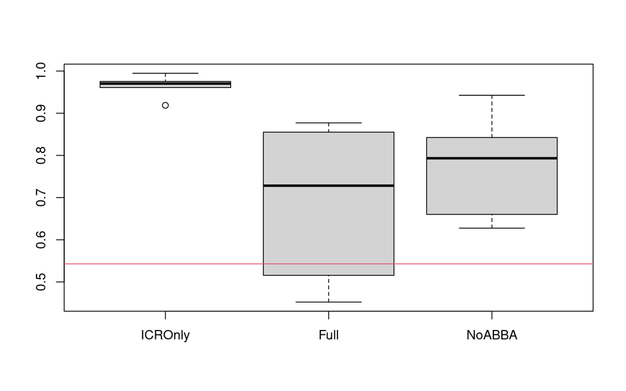

```r
boxplot(ICRBetCor, names = c("ICROnly", "Full", "NoABBA"))
abline(h = cor(betweenness(as.sociomatrix.eventlist(WTCPoliceCalls,
   37)), WTCPoliceIsICR), col = 2)
```

## Section 2. Dyadic Relational Event Models with `rem.dyad`: Exact Timing

In the previous section, we considered dyadic relational event models in the case for which only ordinal timing information is available. We now proceed to the case of exact timing, in which we know the time at which each event occurs (relative to the onset of observation, which is treated as time 0).

### 2.0 The McFarland classroom data

For this section, we will make use of data collected by Dan McFarland (and published in Bender-deMoll and McFarland, 2006) on interaction among students and instructors within a high school classroom. (Note that the data employed here has been slightly modified from the original for illustrative purposes, in that small timing adjustments have been made to separate closely spaced events; those interested in using it for purposes other than practice are directed to the above paper in the Journal of Social Structure.) To see the event data itself, we may print it as follows:

```r
head(Class)
```

```
  StartTime FromId ToId
1     0.135     14   12
2     0.270     12   14
3     0.405     18   12
4     0.540     12   18
5     0.675      1   12
6     0.810     12    1
```

```r
tail(Class)
```

```
    StartTime FromId ToId
687    50.426      1    3
688    50.547      3    1
689    50.668      6   17
690    50.789      6   17
691    50.910     17    6
692    50.920     NA   NA
```

As before, we have three columns: the event time, the event source (numbered from 1 to 20), and the event target (again, numbered 1 to 20). In this case, event time is given in increments of minutes from onset of observation. Note that the last row of the event list contains the time at which observation was terminated; it (and only it!) is allowed to contain `NAs`, since it has no meaning except to set the period during which events could have occurred. Where exact timing is used, the final entry in the edgelist is always interpreted in this way, and any source/target information on this row is ignored.

In addition to the `Class` edgelist, we also observe the covariates `ClassIsTeacher` (an indicator for instructor role) and `ClassIsFemale` (an indicator for gender). Visualizing the data in time-aggregate form gives us the following:

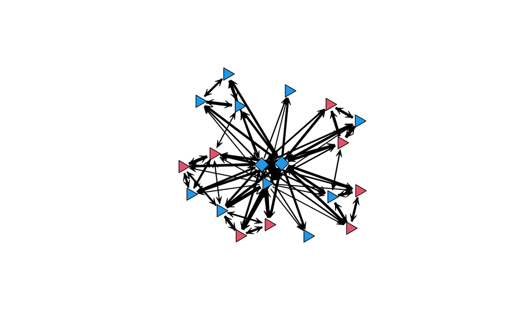

```r
ClassNet <- as.sociomatrix.eventlist(Class, 20)
gplot(ClassNet, vertex.col = 4 - 2 * ClassIsFemale, vertex.sides = 3 +
   ClassIsTeacher, vertex.cex = 2, edge.lwd = ClassNet^0.75)
```

A dynamic visualization for this data is also available in the above-cited paper, and is well worth examining! (The `ndtv` package in `statnet` can be used to produce visualizations of this kind.)

### 2.1 Modeling with covariates

We begin our investigation of classroom dynamics with a trivial intercept model, containing only a vector of 1s (`ClassIntercept`) as a sending effect:

```r
classfit1 <- rem.dyad(Class, n = 20, effects = c("CovSnd"), covar = list(CovSnd = ClassIntercept),
   ordinal = FALSE, hessian = TRUE)
```

```
Prepping edgelist.
Checking/prepping covariates.
Computing preliminary statistics
Fitting model
Obtaining goodness-of-fit statistics
```

```r
summary(classfit1)
```

```
Relational Event Model (Temporal Likelihood)

          Estimate   Std.Err Z value  Pr(>|z|)
CovSnd.1 -3.332287  0.038042 -87.596 < 2.2e-16 ***
---
Signif. codes:  0 '***' 0.001 '**' 0.01 '*' 0.05 '.' 0.1 ' ' 1
Null deviance: 5987.221 on 691 degrees of freedom
Residual deviance: 5987.221 on 691 degrees of freedom
    Chi-square: -7.003109e-11 on 0 degrees of freedom, asymptotic p-value 1
AIC: 5989.221 AICC: 5989.227 BIC: 5993.759
```

Note that we must tell `rem.dyad` that we do not want to discard timing information (`ordinal=FALSE`). The model does not fit any better than the null because it is equivalent to the null model (but you must supply your own intercept, regardless!). As one would expect from first principles, this is really just an exponential waiting time model, calibrated to the observed communication rate:

```r
(classfit1$m - 1)/max(Class[, 1])  #Events per minute (on average)
```

```
[1] 13.57031
```

```r
20 * 19 * exp(classfit1$coef)  #Predicted events per minute (matches well!)
```

```
CovSnd.1
13.57031
```

To make things more interesting, let’s add effects for role and gender:

```r
classfit2 <- rem.dyad(Class, n = 20, effects = c("CovSnd", "CovRec"),
   covar = list(CovSnd = cbind(ClassIntercept, ClassIsTeacher,
      ClassIsFemale), CovRec = cbind(ClassIsTeacher, ClassIsFemale)),
   ordinal = FALSE, hessian = TRUE)
```

```
Prepping edgelist.
Checking/prepping covariates.
Computing preliminary statistics
Fitting model
Obtaining goodness-of-fit statistics
```

```r
summary(classfit2)
```

```
Relational Event Model (Temporal Likelihood)

          Estimate   Std.Err  Z value Pr(>|z|)
CovSnd.1 -3.834231  0.078842 -48.6319  < 2e-16 ***
CovSnd.2  1.672565  0.091679  18.2437  < 2e-16 ***
CovSnd.3  0.123898  0.094931   1.3051  0.19185
CovRec.1  0.373733  0.127028   2.9421  0.00326 **
CovRec.2  0.165735  0.080896   2.0487  0.04049 *
---
Signif. codes:  0 '***' 0.001 '**' 0.01 '*' 0.05 '.' 0.1 ' ' 1
Null deviance: 5987.221 on 691 degrees of freedom
Residual deviance: 5652.318 on 687 degrees of freedom
    Chi-square: 334.9034 on 4 degrees of freedom, asymptotic p-value 0
AIC: 5662.318 AICC: 5662.405 BIC: 5685.008
```

```r
classfit1$BIC - classfit2$BIC  #Model is preferred
```

```
[1] 308.7508
```

Note that covariate effects correspond to the order in which they were specified within the covar argument. It doesn’t look here like gender affects propensity to send; given this, we might wonder whether dropping it gives us a better model.

```r
classfit3 <- rem.dyad(Class, n = 20, effects = c("CovSnd", "CovRec"),
   covar = list(CovSnd = cbind(ClassIntercept, ClassIsTeacher),
      CovRec = cbind(ClassIsTeacher, ClassIsFemale)), ordinal = FALSE,
   hessian = TRUE)
```

```
Prepping edgelist.
Checking/prepping covariates.
Computing preliminary statistics
Fitting model
Obtaining goodness-of-fit statistics
```

```r
summary(classfit3)
```

```
Relational Event Model (Temporal Likelihood)

          Estimate   Std.Err  Z value  Pr(>|z|)
CovSnd.1 -3.775225  0.063622 -59.3379 < 2.2e-16 ***
CovSnd.2  1.615761  0.079933  20.2139 < 2.2e-16 ***
CovRec.1  0.371753  0.127019   2.9267  0.003425 **
CovRec.2  0.161156  0.080815   1.9941  0.046138 *
---
Signif. codes:  0 '***' 0.001 '**' 0.01 '*' 0.05 '.' 0.1 ' ' 1
Null deviance: 5987.221 on 691 degrees of freedom
Residual deviance: 5654.016 on 688 degrees of freedom
    Chi-square: 333.2049 on 3 degrees of freedom, asymptotic p-value 0
AIC: 5662.016 AICC: 5662.074 BIC: 5680.169
```

```r
classfit2$BIC - classfit3$BIC  #Reduced model is indeed preferred
```

```
[1] 4.839661
```

### 2.2 Endogenous social dynamics

The above model is still relatively poor, in the sense that the reduction in deviance is unimpressive. What else might explain classroom communication? Recency effects would seem to be a reasonable bet:

```r
classfit4 <- rem.dyad(Class, n = 20, effects = c("CovSnd", "CovRec",
   "RRecSnd", "RSndSnd"), covar = list(CovSnd = cbind(ClassIntercept,
   ClassIsTeacher), CovRec = cbind(ClassIsTeacher, ClassIsFemale)),
   ordinal = FALSE, hessian = TRUE)
```

```
Prepping edgelist.
Checking/prepping covariates.
Computing preliminary statistics
Fitting model
Obtaining goodness-of-fit statistics
```

```r
summary(classfit4)
```

```
Relational Event Model (Temporal Likelihood)

          Estimate   Std.Err  Z value  Pr(>|z|)
RRecSnd   4.153291  0.119900  34.6397 < 2.2e-16 ***
RSndSnd  -1.399517  0.133149 -10.5109 < 2.2e-16 ***
CovSnd.1 -4.467620  0.075244 -59.3749 < 2.2e-16 ***
CovSnd.2  1.448491  0.080958  17.8919 < 2.2e-16 ***
CovRec.1 -1.364383  0.139346  -9.7913 < 2.2e-16 ***
CovRec.2  0.270105  0.083327   3.2415  0.001189 **
---
Signif. codes:  0 '***' 0.001 '**' 0.01 '*' 0.05 '.' 0.1 ' ' 1
Null deviance: 5987.221 on 691 degrees of freedom
Residual deviance: 4522.646 on 686 degrees of freedom
    Chi-square: 1464.575 on 5 degrees of freedom, asymptotic p-value 0
AIC: 4534.646 AICC: 4534.769 BIC: 4561.875
```

```r
classfit3$BIC - classfit4$BIC  #Enhanced model is preferred
```

```
[1] 1118.294
```

This certainly helps, but we may suspect that more structure is present. Although a classroom is not as structured as a radio channel, we might reasonably expect to see at least modest adherence to conversational norms such as turn-taking. Moreover, sequential address and “hand-offs” might also be expected to occur more frequently here than would be expected by chance. To examine these possibilities, we incorporate the appropriate P-shift effects into our cumulative model:

```r
classfit5 <- rem.dyad(Class, n = 20, effects = c("CovSnd", "CovRec",
   "RRecSnd", "RSndSnd", "PSAB-BA", "PSAB-AY", "PSAB-BY"), covar = list(CovSnd = cbind(ClassIntercept,
   ClassIsTeacher), CovRec = cbind(ClassIsTeacher, ClassIsFemale)),
   ordinal = FALSE, hessian = TRUE)
```

```
Prepping edgelist.
Checking/prepping covariates.
Computing preliminary statistics
Fitting model
Obtaining goodness-of-fit statistics
```

```r
summary(classfit5)
```

```
Relational Event Model (Temporal Likelihood)

          Estimate   Std.Err  Z value  Pr(>|z|)
RRecSnd   2.429211  0.155365  15.6355 < 2.2e-16 ***
RSndSnd  -0.986714  0.144667  -6.8206 9.068e-12 ***
CovSnd.1 -5.003427  0.090609 -55.2203 < 2.2e-16 ***
CovSnd.2  1.253884  0.085160  14.7239 < 2.2e-16 ***
CovRec.1 -0.722692  0.141951  -5.0912 3.559e-07 ***
CovRec.2  0.047961  0.081325   0.5898    0.5554
PSAB-BA   4.622108  0.137600  33.5909 < 2.2e-16 ***
PSAB-BY   1.677543  0.164932  10.1711 < 2.2e-16 ***
PSAB-AY   2.869969  0.103113  27.8334 < 2.2e-16 ***
---
Signif. codes:  0 '***' 0.001 '**' 0.01 '*' 0.05 '.' 0.1 ' ' 1
Null deviance: 5987.221 on 691 degrees of freedom
Residual deviance: 2803.315 on 683 degrees of freedom
    Chi-square: 3183.906 on 8 degrees of freedom, asymptotic p-value 0
AIC: 2821.315 AICC: 2821.58 BIC: 2862.158
```

```r
classfit4$BIC - classfit5$BIC  #Enhanced model is again preferred
```

```
[1] 1699.716
```

Note that, while P-shift effects are certainly present, including them has led the remaining gender effect to fall out. This suggests the possibility that what seemed at first to be a difference in communication receipt tendency by gender was in fact a result of social dynamics (perhaps stemming from the fact that the instructors are male, with their inherent tendency to communicate more often amplified by local conversational norms). Does dropping gender now result in improved model fit? Let’s check.

```r
classfit6 <- rem.dyad(Class, n = 20, effects = c("CovSnd", "CovRec",
   "RRecSnd", "RSndSnd", "PSAB-BA", "PSAB-AY", "PSAB-BY"), covar = list(CovSnd = cbind(ClassIntercept,
   ClassIsTeacher), CovRec = ClassIsTeacher), ordinal = FALSE,
   hessian = TRUE)
```

```
Prepping edgelist.
Checking/prepping covariates.
Computing preliminary statistics
Fitting model
Obtaining goodness-of-fit statistics
```

```r
summary(classfit6)
```

```
Relational Event Model (Temporal Likelihood)

          Estimate   Std.Err  Z value  Pr(>|z|)
RRecSnd   2.430694  0.155292  15.6524 < 2.2e-16 ***
RSndSnd  -0.984647  0.144654  -6.8069 9.972e-12 ***
CovSnd.1 -4.983905  0.084196 -59.1944 < 2.2e-16 ***
CovSnd.2  1.257296  0.084966  14.7976 < 2.2e-16 ***
CovRec.1 -0.745128  0.136612  -5.4543 4.915e-08 ***
PSAB-BA   4.623687  0.137503  33.6261 < 2.2e-16 ***
PSAB-BY   1.677815  0.164940  10.1723 < 2.2e-16 ***
PSAB-AY   2.870503  0.103103  27.8411 < 2.2e-16 ***
---
Signif. codes:  0 '***' 0.001 '**' 0.01 '*' 0.05 '.' 0.1 ' ' 1
Null deviance: 5987.221 on 691 degrees of freedom
Residual deviance: 2803.662 on 684 degrees of freedom
    Chi-square: 3183.558 on 7 degrees of freedom, asymptotic p-value 0
AIC: 2819.662 AICC: 2819.874 BIC: 2855.968
```

```r
classfit5$AICC - classfit6$AICC  #Reduced model is indeed preferred
```

```
[1] 1.705912
```

At this point, we have a relatively simple model that incorporates some plausible social mechanisms. We could continue to elaborate it, but for instructional purposes we stop our search here.

### 2.3 Using a fitted model to investigate event timing

One use of a fitted relational event model is to consider the inter-event times predicted to be observed under various scenarios. For this purpose, it is useful to remember that, under the piecewise constant hazard assumption, event waiting times are conditionally exponentially distributed. This allows us to easily work out the consequences of various model effects for social dynamics, at least within the context of a particular scenario.

In interpreting coefficient effects, recall that they act as logged hazard multipliers. For instance:

```r
exp(classfit6$coef["PSAB-BA"])  #Response events have apx 100 times the hazard of other events
```

```
 PSAB-BA
101.8689
```

Remember, however, that the fact that an event has an unusually high hazard does not mean that it will necessarily occur. For instance, while a response of B to a communication from A has a hazard that is (*ceteris paribus*) about 100 times as great as the hazard of a non B$\to$A event, there are many more events of the latter type. Here, indeed, there are 379 other events “competing” with the B$\to$A response, and thus the chance that the latter will occur next is smaller than it may appear. Both relative rates and combinatorics (i.e., the number of possible ways that an event type may occur) govern the result.

One basic use of the model coefficients is to examine the expected inter-event times under specific scenarios. E.g.:

```r
# Mean inter-event time if nothing else going on....
1/(20 * 19 * exp(classfit6$coef["CovSnd.1"]))
```

```
CovSnd.1
0.384325
```

```r
# Mean teacher-student time (again, if nothing else
# happened)
1/(2 * 18 * exp(sum(classfit6$coef[c("CovSnd.1", "CovSnd.2")])))
```

```
[1] 1.153833
```

```r
# Sequential address by teacher w/out prior interaction,
# given a prior teacher-student interaction, and assuming
# nothing else happened
1/(17 * exp(sum(classfit6$coef[c("CovSnd.1", "CovSnd.2", "PSAB-AY")])))
```

```
[1] 0.138469
```

```r
# Teacher responding to a specific student, given an
# immediate event
1/(exp(sum(classfit6$coef[c("CovSnd.1", "CovSnd.2", "PSAB-BA",
   "RRecSnd")])))
```

```
[1] 0.03587293
```

```r
# Student responding to a specific teacher, given an
# immediate event
1/(exp(sum(classfit6$coef[c("CovSnd.1", "CovRec.1", "PSAB-BA",
   "RRecSnd")])))
```

```
[1] 0.2657105
```

Again, the number of ways that an event type can occur and the propensity of such events to occur both matter!

### 2.4 Assessing model adequacy

Model adequacy assessment in the exact timing case is much like that of the ordinal case. We cannot here use a fixed null residual or guessing equivalent, but can still look at “surprise” based on deviance residuals:

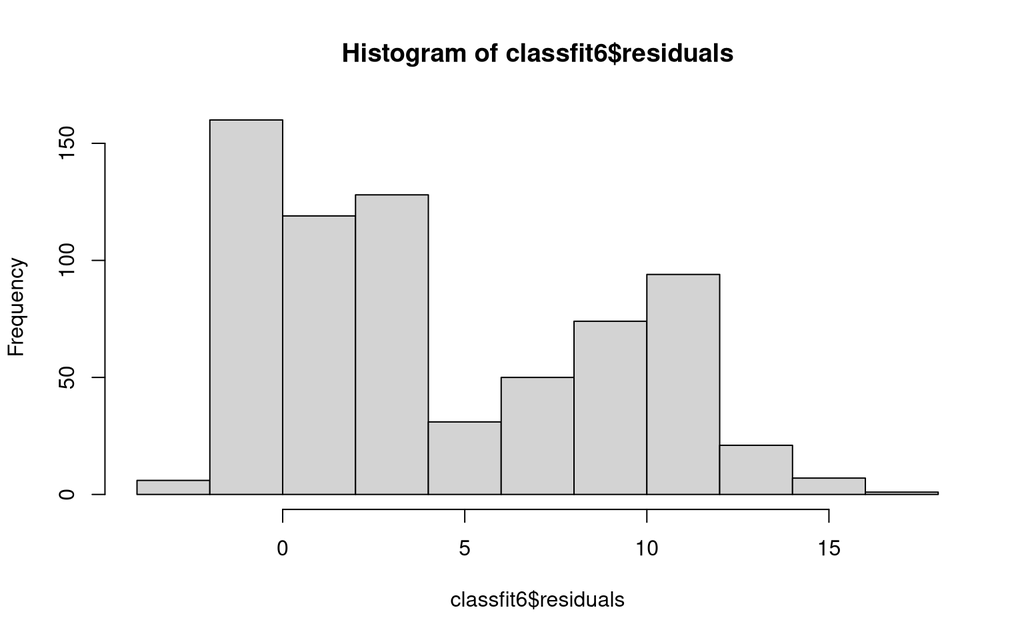

```r
# Where is the model 'surprised'? Can't use null residual
# trick, but can see what the distribution looks like
hist(classfit6$residuals)  #Deviance residuals - lumpier by far, most smallish
```

The fit here doesn’t seem to be as good as it was for the WTC police data. Let’s look at classification:

```r
mean(apply(classfit6$predicted.match, 1, all))  #Exactly right about 33%
```

```
[1] 0.3299566
```

```r
mean(apply(classfit6$predicted.match, 1, any))  #Get one party exactly right 52%
```

```
[1] 0.5166425
```

```r
colMeans(classfit6$predicted.match)  #Better at sender than receiver!
```

```
   FromId      ToId
0.5050651 0.3415340
```

```r
classfit6$observed.rank
```

```
  [1]   1   1  58   1  77   1  39   1   3   4   4   4   4   4  19   4   4   4
 [19]   4   3   3   4   4   1   3   4   4  54   3   3   3   3   3   3   3   3
 [37]   3   3   3   2   2   3   3   3   3   3  92   1   5   1   4   1   4   1
 [55]   4   1  40   1  65   6  11   9  20   7   8   4  10  99   1   1   1  59
 [73]   3   3  14  14   3   3   3  12   3  10   3   2   2   3   3   3   3   3
 [91]  23   1   3   4   4   4   4   4   4   4   4   4   4   4   3   3   4   1
[109]   3   4   4 374   1 110   1  59   4   4   4   4   4   4   4   4   4   4
[127]   4   3   3   4   1   3   4   4 106   1 123   1  60   4   4   4   4   4
[145]   4   4   4   4   4   4   3   3   4   1   3   4   4 111   8   8   5   7
[163]   2  10   8   6   7   3   7   7  14   8   8   8   8   8 122   1 125   1
[181] 115   1 130   1  86   2  10   1  29   1  47   1 115   1 110   1  48   1
[199]   1   1  61   1  36   1   8   1   8   1 130   1   1   1 133   1  50   1
[217]  89   1  98   2   4   2  33   1 119   1  94   1  51   1 122   1   2   1
[235]   2   1  50   1 117   1  51   1   3   1 131   1  88   1  27   1  32   1
[253]  74   1  53   1 119   1 121   1  52   1  52   1  91   1 128   1  54   1
```

[output cut: 24 more lines]

```r
cbind(Class, c(classfit6$observed.rank, NA))
```

```
    StartTime FromId ToId c(classfit6$observed.rank, NA)
1       0.135     14   12                              1
2       0.270     12   14                              1
3       0.405     18   12                             58
4       0.540     12   18                              1
5       0.675      1   12                             77
6       0.810     12    1                              1
7       0.945     14   17                             39
8       1.080     17   14                              1
9       1.257     14    1                              3
10      1.267     14    2                              4
11      1.277     14    3                              4
12      1.287     14    4                              4
13      1.297     14    5                              4
14      1.307     14    6                              4
```

[output cut: 678 more lines]

It looks like there is some structure in the errors: we aren’t able to capture certain kinds of intrusive events. Does looking at the “surprising” events (say, those for which the observed event is not in the top 5% of those predicted) in time-aggregate form help?

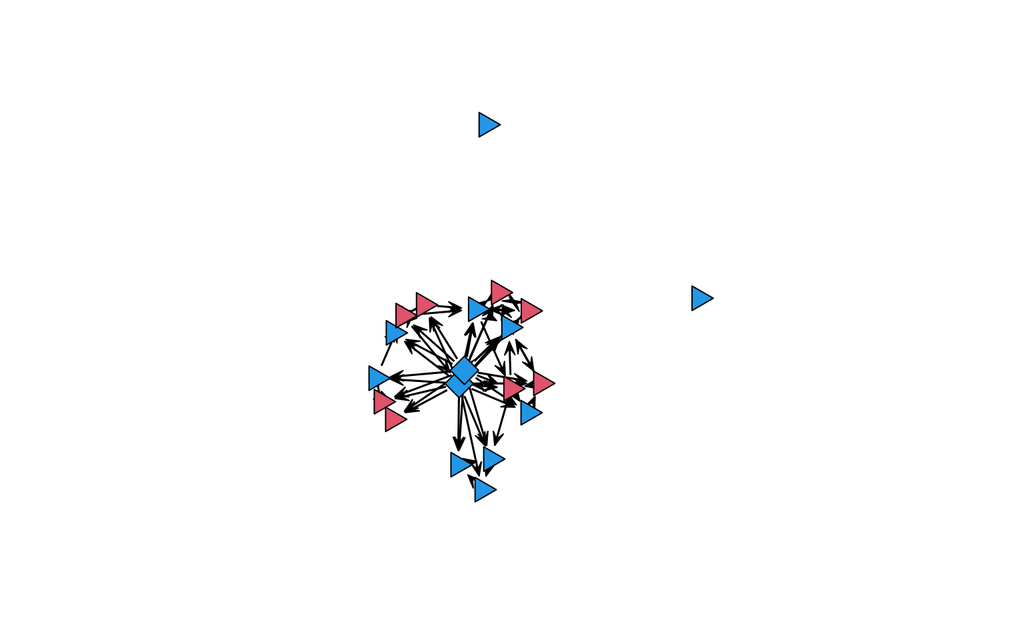

```r
# Get the surprising events, and display as a network
surprising <- as.sociomatrix.eventlist(Class[classfit6$observed.rank >
   19, ], 20)
gplot(surprising, vertex.col = 4 - 2 * ClassIsFemale, vertex.sides = 3 +
   ClassIsTeacher, vertex.cex = 2)
```

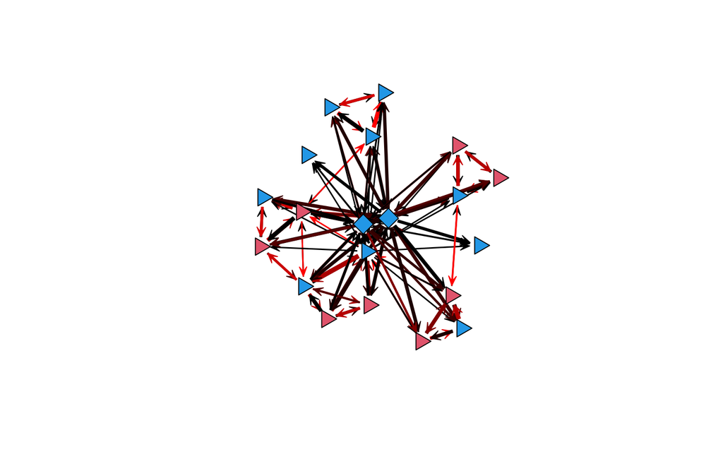

```r
# Show how the 'surprising' events fit into the broader
# communication structure
edgecol <- matrix(rgb(surprising/(ClassNet + 0.01), 0, 0), 20,
   20)  #Color me surprised
gplot(ClassNet, edge.col = edgecol, edge.lwd = ClassNet^0.75,
   vertex.col = 4 - 2 * ClassIsFemale, vertex.sides = 3 + ClassIsTeacher,
   vertex.cex = 2)
```

The visualization gives us more of a clue about what we’re missing: various side discussions occur that are not well-captured by the current model. This could be due to the fact that things like P-shift effects fail to capture simultaneous side conversations (each of which may have its own set of turn-taking patterns), or to a lack of covariates to capture the enhanced propensity of subgroup members to address each other. Further elaboration could be helpful here. On the other hand, we seem to be doing reasonably well at capturing the main line of discussion within the classroom, particularly vis a vis the instructors. Whether or not this is adequate depends on the purpose to which the model is to be put; as always, adequacy must be considered in light of specific scientific goals.

### 2.5 Simulating from the fitted model

Simulation from fitted models with exact timing proceeds exactly as in the ordinal timing case: we can use the `simulate` method for `rem.dyad` to generate trajectories from the fitted model object.

For instance, to generate a new trajectory from the final classroom model, we would use the code

```r
set.seed(1331)
ClassSim <- simulate(classfit6, covar = list(CovSnd = cbind(ClassIntercept,
   ClassIsTeacher), CovRec = ClassIsTeacher))

ClassSim  #Examine the resulting trajectory
```

```
             [,1] [,2] [,3]
  [1,]  0.2452372    7    1
  [2,]  0.2648195    1    7
  [3,]  0.2823672    7   18
  [4,]  0.3090297   13   19
  [5,]  0.3387736    7    2
  [6,]  0.4176939   15   19
  [7,]  0.4333086   14   16
  [8,]  0.4465340   14   18
  [9,]  0.5291581   14    9
 [10,]  0.6368619   14   10
 [11,]  0.7403585   10   14
 [12,]  0.8529512   14   18
 [13,]  0.8781311   14   10
 [14,]  0.9604370   14   12
```

[output cut: 680 more lines]

As we saw in section 1.5, running the `simulate` command on the fitted model object produces a new trajectory of identical length to the original, with the same coefficients. Note that the new trajectory is identical in terms of the number of *realized events* it contains, and it will not in general cover the same *time period.* Some disparity between the two is normal (and, indeed, will happen with probability 1); however, when the total mean time period of the replicate sequences is substantially different from that of the original data, this suggests that the pacing of the model is off.

In section 1.5, we showed how an *in silico* knock-out study could be used to gain insights into model behavior. Another useful strategy can be to simulate trajectories from a fitted model with alternative choices of covariates. For instance, what might we expect if we replaced the teachers in our classroom with students? This anarchic state of affairs can be probed by conditional simulation with a different set of covariates:

```r
set.seed(1331)
AnarchSim <- simulate(classfit6, covar = list(CovSnd = cbind(ClassIntercept,
   rep(0, 20)), CovRec = rep(0, 20)))

AnarchSim  #Examine the trajectory
```

```
             [,1] [,2] [,3]
  [1,]  0.2923476   10    2
  [2,]  0.3138169    2   10
  [3,]  0.3510402   10   11
  [4,]  0.3835927   16   10
  [5,]  0.4142638   10    9
  [6,]  0.5083167   17   10
  [7,]  0.5244295    8    2
  [8,]  0.5389847    2    8
  [9,]  0.6802120    2    9
 [10,]  0.7892631    2   10
 [11,]  0.9134020   10    2
 [12,]  1.1401766   12    9
 [13,]  1.1722723    9   12
 [14,]  1.2860364    9    5
```

[output cut: 680 more lines]

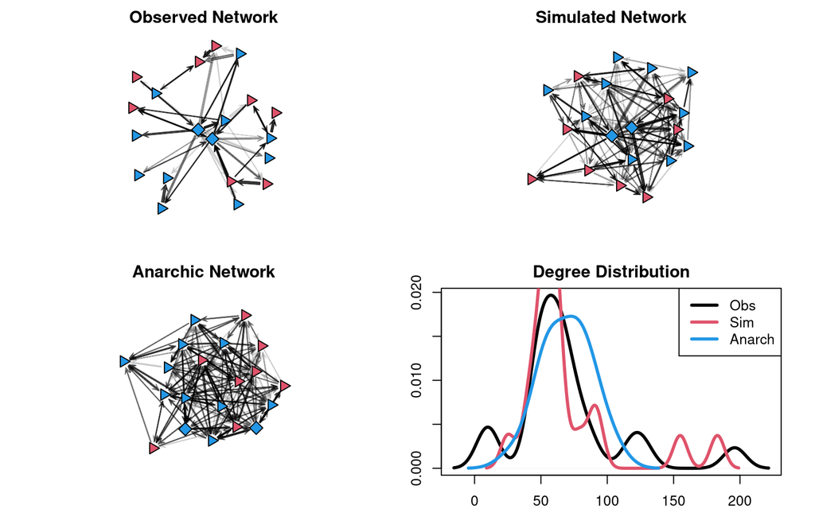

```r
# Plot the network structure of the simulations, and the
# observed data
par(mfrow = c(2, 2), mar = c(2, 2, 2, 2))
gplot(ClassNet, vertex.col = 4 - 2 * ClassIsFemale, vertex.sides = 3 +
   ClassIsTeacher, vertex.cex = 2, edge.lwd = ClassNet^0.75,
   main = "Observed Network", edge.col = rgb(0, 0, 0, (1 - 1/(1 +
      ClassNet))^3))
SimNet <- as.sociomatrix.eventlist(ClassSim, 20)  #Create a network from the fitted sim
gplot(SimNet, vertex.col = 4 - 2 * ClassIsFemale, vertex.sides = 3 +
   ClassIsTeacher, vertex.cex = 2, edge.lwd = SimNet^0.75, main = "Simulated Network",
   edge.col = rgb(0, 0, 0, (1 - 1/(1 + SimNet))^3))
AnarchNet <- as.sociomatrix.eventlist(AnarchSim, 20)  #Create a network from the anarchy sim
gplot(AnarchNet, vertex.col = 4 - 2 * ClassIsFemale, vertex.sides = 3 +
   ClassIsTeacher, vertex.cex = 2, edge.lwd = AnarchNet^0.75,
   main = "Anarchic Network", edge.col = rgb(0, 0, 0, (1 - 1/(1 +
      AnarchNet))^3))

# Plot the valued degree distributions
plot(density(degree(ClassNet), bw = "SJ"), lwd = 3, main = "Degree Distribution")
lines(density(degree(SimNet), bw = "SJ"), lwd = 3, col = 2)
lines(density(degree(AnarchNet), bw = "SJ"), lwd = 3, col = 4)
legend("topright", legend = c("Obs", "Sim", "Anarch"), lwd = 3,
   col = c(1, 2, 4))
```

Comparing the plots, we can see several things. First, we note some limitations of our fitted model: while it does relatively well at ensuring that the teachers are central, enduring that many of the strongest interactions are student-teacher interactions, creating a network in which strong interactions are localized to a fairly small number of (highly reciprocal) dyads, and reproducing the overall valued degree distribution, it also produces a large “halo” of weak side-interactions among the students that is not seen in the observed network. This suggests the potential for further model improvement.

Turning to our “anarchy in the classroom” model, however, we see that the effect of removing teachers is substantively reasonable. The nodes that were formerly teachers no longer have any particular significance, and are now well-mixed with their peers; likewise, without the teachers to focus attention, the network is as a whole much less centralized. Thus, the model does plausibly produce many of the effects one would expect to see from such a change in group composition. Such scenario-based probes can be a useful tool for assessing model behavior, as well as being of possible substantive interest in and of themselves.

## Section 3. Simulating *De Novo* Dyadic Relational Event Models

We have seen how the `simulate` command can be used to simulate draws from fitted `rem.dyad` objects, and even how these may be modified by switching coefficients or covariates for particular purposes. What if we want to create a *de novo* simulation? This can also be done, using `rem.dyad` to create a *model skeleton* that can subsequently be used for simulation.

### 3.0 Creating a model skeleton

To set up a REM for simulation, we need to create an object that records the system size (i.e., number of vertices), effects involved, and other critical information. When we fit models using `rem.dyad’’, this information was encoded in the model object. In the *de novo* case, we use the same approach - except that we simply omit the data!

To see how this is done, let’s consider an example. Let us say that we want to create a model for a 25-node REM with a baseline intercept, an AB-BA P-shift, and a recency effect of sending on future sending (`RSndSnd`). We then proceed by creating a model just as we would normally, but with `NULL` where the data should be:

```r
ModInt <- rep(1, 25)
modskel <- rem.dyad(NULL, n = 25, effects = c("CovSnd", "PSAB-BA",
   "RSndSnd"), covar = list(CovSnd = ModInt))
```

```
NULL edgelist passed to rem.dyad - creating model skeleton.
Checking/prepping covariates.
```

```r
modskel
```

```
Relational Event Model
    Model skeleton (not fit)

Embedded coefficients:
      RSndSnd      CovSnd.1       PSAB-BA
 0.0004960916  0.0007342584 -0.0007378757
```

Note that the model is correctly identified as a skeleton, with a reminder that it was not fit to data. It also comes equipped with “default” coefficients, but these are not very useful: if a seed coefficient is not passed, `rem.dyad` always initializes with perturbed coefficients near zero. If one knows what coefficients one wants to embed in the skeleton, one can set them using the `coef.seed` argument.

Note that none of the inferential or other arguments to `rem.dyad` are needed here, since no fitting is done. Perhaps less obviously, we do not need to set the `ordinal` variable, since all REM simulation is done in continuous time. (The resulting trajectories can, of course, be interpreted ordinally, if the pacing constant used was arbitrary.)

### 3.1 Simulating from the model skeleton

Simulation from the model skeleton is then performed just as simulation with fitted model objects, except that one needs to pass the number of draws to take (`nsim`, which was optional before) and `coef` (unless one already embedded the coefficients one wants in the model object). Be sure to enter your coefficients in the order stored in the skeleton, which may not be the order you initially specified the effects! Let’s see how this works, using our example:

```r
set.seed(1331)
modsim <- simulate(modskel, nsim = 100, coef = c(0.25, -1, 4),
   covar = list(CovSnd = ModInt))
head(modsim)  #See the trajectory
```

```
            [,1] [,2] [,3]
[1,] 0.003446229   20    2
[2,] 0.004616100    9    6
[3,] 0.005879407   25   17
[4,] 0.007751835   10   23
[5,] 0.009434835    9   20
[6,] 0.015124865   14   23
```

```r
grecip(as.sociomatrix.eventlist(modsim, 25), measure = "edgewise")  #Relatively reciprocal
```

```
      Mut
0.2444444
```

Any number of events may be simulated in this way.

### 3.2 Simulation with time-varying covariates

Time-varying covariates must, by definition, be specified at each time step. `rem.dyad` understands several covariate formats (see `?rem.dyad`):

```r
set.seed(1331)
# Set up the model
tcovar <- array(sweep(sapply(1:10, rep, 100), 1, 1/1.05^(0:99),
   "*"), dim = c(100, 10, 1))
SndInt <- rep(1, 10)
# Note that, in making the skeleton, we need to pass the
# covariates as if they are static - that's because the
# model doesn't contain time points yet.
modskel2 <- rem.dyad(NULL, n = 10, effects = c("CovSnd", "CovInt"),
   coef.seed = c(-1, 1), covar = list(CovSnd = SndInt, CovInt = tcovar[1,
      , 1]))
```

```
NULL edgelist passed to rem.dyad - creating model skeleton.
Checking/prepping covariates.
```

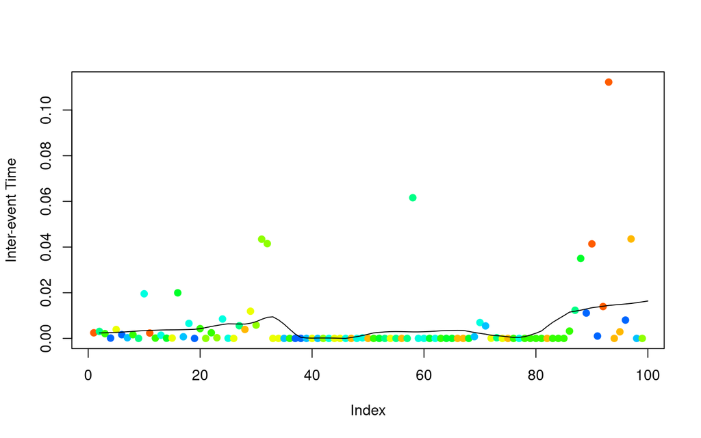

```r
# Simulate draws
modsim2 <- simulate(modskel2, nsim = 100, covar = list(CovSnd = SndInt,
   CovInt = tcovar))

# Note that dynamics slow down, and participation evens out
plot(diff(modsim2[, 1]), col = hsv(modsim2[, 2]/10 * 0.6), pch = 19,
   ylab = "Inter-event Time")
lines(supsmu(x = 2:100, y = diff(modsim2[, 1])))
```

On average, dynamics slow down, as we would expect, and more low-numbered (redder) vertices interact after the initial period.

## References

Butts, Carter T. (2008). “A Relational Event Framework for Social Action.” *Sociological Methodology*, 38(1), 155-200.

Butts, Carter T. and Marcum, Christopher S. (2017). “A Relational Event Approach to Modeling Behavioral Dynamics.” In Andrew Pilney and Marshall Scott Poole (Eds.), *Group Processes: Data-Driven Computational Approaches*. Springer.

Butts, Carter T.; Petrescu-Prahova, Miruna; and Cross, B. Remy. (2007). “Responder Communication Networks in the World Trade Center Disaster: Implications for Modeling of Communication Within Emergency Settings.” *Journal of Mathematical Sociology,* 31(2), 121-147.

Marcum, Christopher S. and Butts, Carter T. (2015). “Constructing and Modifying Sequence Statistics for `relevent` using `informR` in `R`.” *Journal of Statistical Software*, 64(5). [https://doi.org/10.18637/jss.v064.i05]

Bender-deMoll, Skye and McFarland, Daniel A. (2006). ``The Art and Science of Dynamic Network Visualization.’’ *Journal of Social Structure*, 7. [https://www.cmu.edu/joss/content/articles/volume7/deMollMcFarland/]